# Analyzing Storm Data For Human and Economic Cost

JDV

June 5, 2018

## Data Processing

```r
# Read raw data and prepare to preprocess
data <- read.csv("repdata_data_StormData.csv.bz2")

stormData <- setDT(data)
```

Once we’ve loaded the data we realize we have 902297 rows and 37 columns. We can get a glimpse of what we’re dealing with using `str()` if we so desire.

We are particularly interested in columns regarding health impact, economic impact and the type of event we’re dealing with. So we’ll take a closer a look at those that seem interesting at a glance:

```r
kable(as.matrix(summary(stormData[, .(EVTYPE, FATALITIES, INJURIES, PROPDMG, CROPDMG)])))
```

|  | EVTYPE | FATALITIES | INJURIES | PROPDMG | CROPDMG |
| --- | --- | --- | --- | --- | --- |
|  | HAIL :288661 | Min. : 0.0000 | Min. : 0.0000 | Min. : 0.00 | Min. : 0.000 |
|  | TSTM WIND :219940 | 1st Qu.: 0.0000 | 1st Qu.: 0.0000 | 1st Qu.: 0.00 | 1st Qu.: 0.000 |
|  | THUNDERSTORM WIND: 82563 | Median : 0.0000 | Median : 0.0000 | Median : 0.00 | Median : 0.000 |
|  | TORNADO : 60652 | Mean : 0.0168 | Mean : 0.1557 | Mean : 12.06 | Mean : 1.527 |
|  | FLASH FLOOD : 54277 | 3rd Qu.: 0.0000 | 3rd Qu.: 0.0000 | 3rd Qu.: 0.50 | 3rd Qu.: 0.000 |
|  | FLOOD : 25326 | Max. :583.0000 | Max. :1700.0000 | Max. :5000.00 | Max. :990.000 |
|  | (Other) :170878 | NA | NA | NA | NA |

We can see that damage values are on different scales depending on the event. We’re gonna have to convert these so that a more straight-forward comparison can be made. The exponentials can be found in the `*EXP` fields. We can also see that there’s no case consistency, so we’ll deal with that as well.

```r
# Ignore rows that only seem to have corrupt data for the exponent
stormData <- stormData[!(PROPDMGEXP %in% c("-", "?", "+"))]
stormData <- stormData[!(CROPDMGEXP %in% c("-", "?", "+"))]

# We get everything to be upper case
stormData$PROPDMGEXP <- factor(toupper(stormData$PROPDMGEXP))
stormData$CROPDMGEXP <- factor(toupper(stormData$CROPDMGEXP))
stormData$EVTYPE <- factor(toupper(stormData$EVTYPE))

# We replace empty exponents with exponent 0 (class 2)
stormData[PROPDMGEXP == "", PROPDMGEXP := as.integer(2)]
stormData[, PROPDMGEXP := factor(PROPDMGEXP)]

# We create an exponent map and get the actual numbers
expMap <- data.frame(c(levels(stormData$PROPDMGEXP)), stringsAsFactors = F)
names(expMap) <- c("val")
row.names(expMap) <- levels(stormData$PROPDMGEXP)
expMap["H", 1] <- 2
expMap["K", 1] <- 3
expMap["M", 1] <- 6
expMap["B", 1] <- 9

stormData[, PROPDMG := PROPDMG * 10^as.integer(expMap[PROPDMGEXP, 1])]
stormData[, CROPDMG := PROPDMG * 10^as.integer(expMap[CROPDMGEXP, 1])]

head(stormData[order(-PROPDMG), PROPDMG])
```

```
## [1] 1.150e+11 3.130e+10 1.693e+10 1.126e+10 1.000e+10 7.350e+09
```

Numbers are looking better now; they’re all on the same scale.

Now we have to deal with the thousands of possible `EVTYPE` values, which complicates things. I’ll just do a lazy cleanup using `grep` and replacing some values, hopefully ending up with something reasonable. Ideally you’d spend more time on this.

```r
stormData[, EVTYPE := as.character(EVTYPE)]
stormData[grepl("HAIL", EVTYPE), EVTYPE := "HAIL"]
stormData[grepl("ICE", EVTYPE), EVTYPE := "ICE"]
stormData[grepl("AVALANC", EVTYPE), EVTYPE := "AVALANCHE"]
stormData[grepl("FOG|VOG", EVTYPE), EVTYPE := "FOG"]
stormData[grepl("FLOOD", EVTYPE), EVTYPE := "FLOOD"]
stormData[grepl("WIND|WND", EVTYPE), EVTYPE := "WIND"]
stormData[grepl("SNOW", EVTYPE), EVTYPE := "SNOW"]
stormData[grepl("WATER|WET|RAIN|PRECIPITATION|SHOWER", EVTYPE), EVTYPE := "WATER"]
stormData[grepl("DUST|LANDSPOUT", EVTYPE), EVTYPE := "DUST"]
stormData[grepl("BLIZZARD", EVTYPE), EVTYPE := "BLIZZARD"]
stormData[grepl("LIGHTNING", EVTYPE), EVTYPE := "LIGHTNING"]
stormData[grepl("TORNADO|TORNDAO", EVTYPE), EVTYPE := "TORNADO"]
stormData[grepl("FUNNEL", EVTYPE), EVTYPE := "FUNNEL CLOUD"]
stormData[grepl("COASTAL", EVTYPE), EVTYPE := "COASTAL"]
stormData[grepl("VOLCAN", EVTYPE), EVTYPE := "VOLCANO"]
stormData[grepl("HURRICANE", EVTYPE), EVTYPE := "HURRICANE"]
stormData[grepl("RIP", EVTYPE), EVTYPE := "RIP CURRENTS"]
stormData[grepl("LIGHTNING", EVTYPE), EVTYPE := "LIGHTNING"]
stormData[grepl("WINTER|WINTR", EVTYPE), EVTYPE := "WINTER"]
stormData[grepl("COLD|COOL|FREEZ|FROST|LOW", EVTYPE), EVTYPE := "COLD"]
stormData[grepl("HOT|HEAT|WARM|DRY|DRIEST|HIGH", EVTYPE), EVTYPE := "HOT"]
stormData[grepl("FIRE", EVTYPE), EVTYPE := "FIRE"]
stormData[grepl("URBAN", EVTYPE), EVTYPE := "URBAN"]
stormData[grepl("THUNDERSTORM|TSTM", EVTYPE), EVTYPE := "THUNDERSTORM"]
stormData[grepl("TROPICAL", EVTYPE), EVTYPE := "TROPICAL"]
stormData[grepl("MUD|LAND", EVTYPE), EVTYPE := "MUD"]
stormData <- stormData[!(grepl("SUMMARY|COUNTY|\\?|MONTH|EXCESSIVE|NONE|WEATHER|TEMPERATU", EVTYPE))]
stormData[, EVTYPE := factor(EVTYPE)]
```

Now the dirty work is done and our `EVTYPE` variable has been normalized.

## Results

In order to get a better sense of the results, we shall create a new variable for the general economic damage generated by the storm. Let’s take a look at the resulting values:

```r
stormData[, DMG := PROPDMG + CROPDMG]
kable(as.matrix(summary(stormData$DMG)))
```

| Min. | 0.000000e+00 |
| --- | --- |
| 1st Qu. | 0.000000e+00 |
| Median | 0.000000e+00 |
| Mean | 1.818369e+10 |
| 3rd Qu. | 2.000000e+03 |
| Max. | 1.150012e+16 |

Good news is we don’t have missing data so we can just go ahead and plot this for each `EVTYPE` and take a look at what we get.

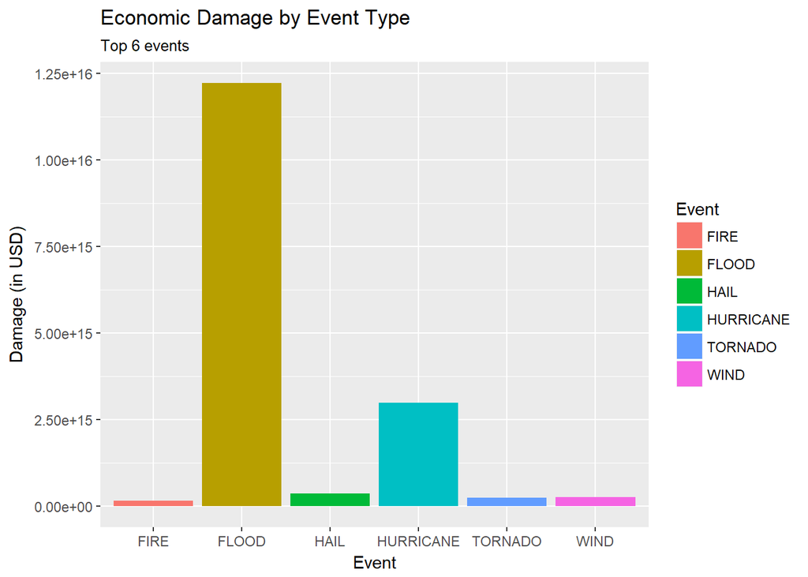

```r
library(ggplot2)
events <- 6

ggplot(head(stormData[, sum(DMG), by=EVTYPE][order(-V1)], n=events),
       aes(x = EVTYPE, y = V1)) +
  geom_bar(aes(fill=EVTYPE), stat="identity") +
  labs(title="Economic Damage by Event Type",x="Event",
       y="Damage (in USD)", subtitle=paste("Top",events,"events"), fill="Event")
```

From the plot above we can tell the flooding causes far more damage than other types of events. The margin is very wide.

```r
stormData[, HEALTHDMG := weight * FATALITIES + INJURIES]
kable(as.matrix(summary(stormData$HEALTHDMG)))
```

| Min. | 0.000000 |
| --- | --- |
| 1st Qu. | 0.000000 |
| Median | 0.000000 |
| Mean | 1.834363 |
| 3rd Qu. | 0.000000 |
| Max. | 58300.000000 |

Now that we have our one field to gauge how many people were affected by the event, we can now get a good estimate of what events are the most disastrous for human life/health.

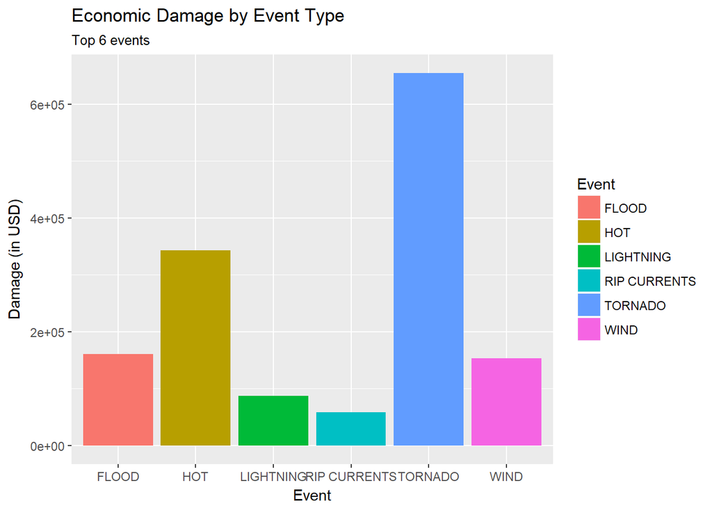

```r
ggplot(head(stormData[, sum(HEALTHDMG), by=EVTYPE][order(-V1)], n=events),
       aes(x = EVTYPE, y = V1)) +
  geom_bar(aes(fill=EVTYPE), stat="identity") +
  labs(title="Economic Damage by Event Type",x="Event",
       y="Damage (in USD)", subtitle=paste("Top",events,"events"), fill="Event")
```

Tornados hurt far more people than any other event. Heat related events and floods come in second and third.